# Plotting and Visualization

EE1021 Programming for Engineers - Lecture 9

Basri Erdogan

## Lecture Goals

1. Understand the structure of a matplotlib graphic: **figure, axes, and line objects**
2. Create line plots and customize **markers, colors, line widths, and line styles**
3. Make plots readable with **titles, axis labels, legends, grids, and axis limits**
4. Choose the right axis scaling: **linear, semilogx, semilogy, and loglog**
5. Combine several plots in one figure with **subplots**
6. Plot complex-valued and periodic data using **polar plots**

# Part 1: First Plots with Matplotlib

## Last Time / Today

**Last time**

- NumPy arrays

**Today: `matplotlib.pyplot`**

- Drawing graphs in Python with Matplotlib’s PyPlot module
- Line graphs and their customization
- Subplotting
- Polar plots

## Visualization

- Visualization is a universal tool for investigating and communicating results of computational studies.
- Knowledge and insights can be most easily gained from computational results when they are visualized.
- There are a number of high-quality visualization libraries for Python.
- The most popular one is **Matplotlib**.
  - Website: http://www.matplotlib.org
  - Main focus is on generating static 2D and 3D graphs.

## Anatomy of a Figure

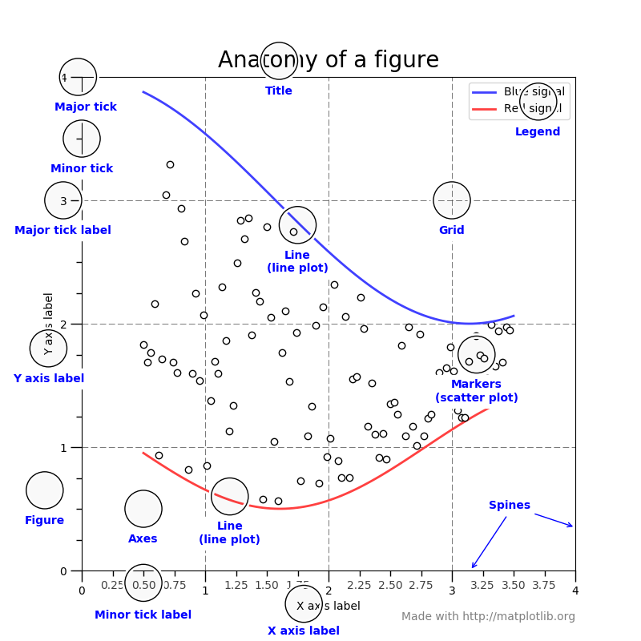

## Figure, Axes, and Line Objects

- The **Figure** is the main instance of a graph window.
- A figure may involve more than one **Axes** area.
  - The axis provides the coordinate system.
- An axes area may involve more than one **Line** object.

## First Plot

To draw a first plot, we:

1. Generate an `x` array.
2. Calculate the `y` array from `x`.
3. Plot `x` versus `y`.

## First Plot: Code

```python
import numpy as np
import matplotlib.pyplot as plt

# generate x array
x = np.arange(-5, 4)

# calculate y from x
y = 5*x + 4

# create figure and axes objects
fig, axs = plt.subplots(1, 1)
lns, = axs.plot(x, y)
```

```python
fig, axs = plt.subplots(1, 1)
lns = axs.plot(x, y)
```

- `fig, axs = plt.subplots(1, 1)`
  - Creates a figure (`fig`)
  - Creates axes (`axs`)
- `lns = axs.plot(x, y)`
  - Plots/creates a line object.
  - `lns` is a **list** of line objects; you can create more than one line object at a time.
  - There is only one line object in this example, so to access the object you need to use `lns[0]`.

## Plot Details

- `x` and `y` are indeed discrete points (coordinates).
- By default, invisible markers are put at these coordinates.
- Matplotlib connects these markers with lines.
- The result is a continuous-looking plot.
- Markers can be set as visible characters with adjustable sizes.
- Line type, color, and size can also be adjusted.

# Part 2: Customizing Line Plots

## Plotting with a Specific Marker

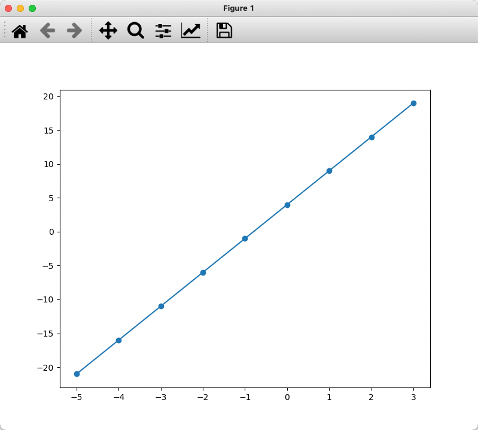

```python
lns, = axs.plot(x, y, marker='o')
```

## Markers

| Symbol | Marker |
| --- | --- |
| `"."` | point |
| `","` | pixel |
| `"o"` | circle |
| `"v"` | triangle_down |
| `"^"` | triangle_up |
| `"<"` | triangle_left |
| `">"` | triangle_right |
| `"1"` | tri_down |
| `"2"` | tri_up |
| `"3"` | tri_left |
| `"4"` | tri_right |
| `"8"` | octagon |

| Symbol | Marker |
| --- | --- |
| `"s"` | square |
| `"p"` | pentagon |
| `"P"` | plus (filled) |
| `"*"` | star |
| `"h"` | hexagon1 |
| `"H"` | hexagon2 |
| `"+"` | plus |
| `"x"` | x |
| `"X"` | x (filled) |
| `"D"` | diamond |
| `"d"` | thin_diamond |
| `"\\|"` | vline |
| `"_"` | hline |

## Marker Size

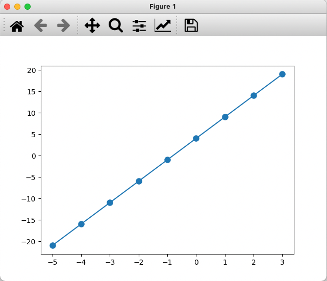

```python
plt.plot(x, y, marker='o', markersize=8)
```

## Line Color

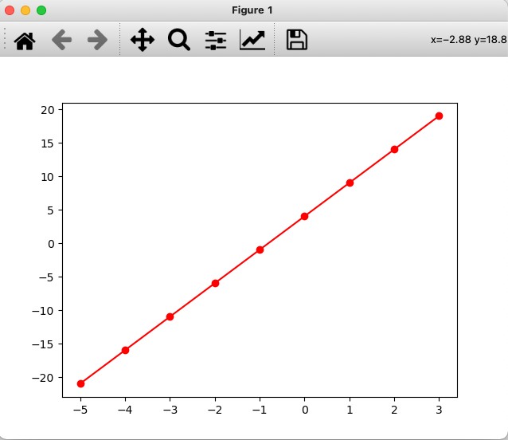

```python
lns, = axs.plot(x, y, marker='o', color='r')
```

## Colors

Fast color names:

| Code | Color | Code | Color |
| --- | --- | --- | --- |
| `'b'` | blue | `'m'` | magenta |
| `'g'` | green | `'y'` | yellow |
| `'r'` | red | `'k'` | black |
| `'c'` | cyan | `'w'` | white |

## Line Width (`lw`)

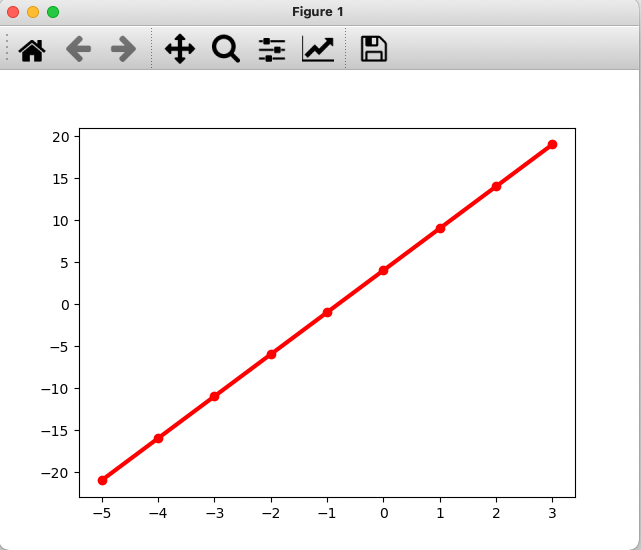

```python
lns, = axs.plot(x, y, marker='o', color='r', lw=3)
```

## Line Style (`ls`)

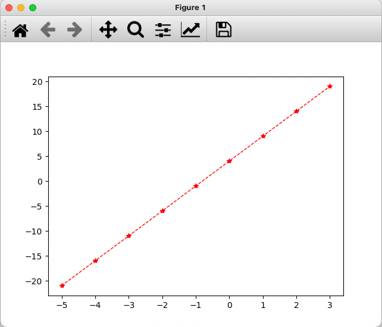

```python
lns = axs.plot(x, y, marker='*', color='r', lw=1, ls='--')
```

## Line Styles

Set with the `linestyle` (or `ls`) keyword:

| Value | Style |
| --- | --- |
| `'-'` | solid |
| `'--'` | dashed |
| `':'` | dotted |
| `'-.'` | dash-dotted |

# Part 3: Multiple Lines, Legends, and Labels

## Adding a Second Plot: Code

```python
import numpy as np
import matplotlib.pyplot as plt

# generate x array
x = np.arange(-5, 4, .1)

# calculate y and d
y = 5*x + 4
d = x**2 + 2*x - 3

# create figure and axes objects
fig, axs = plt.subplots(1, 1)
lns = axs.plot(x, y, x, d)  # lns is a list of two line objects
```

## Adding a Second Plot: Result

- Colors are automatically assigned (if not specified).

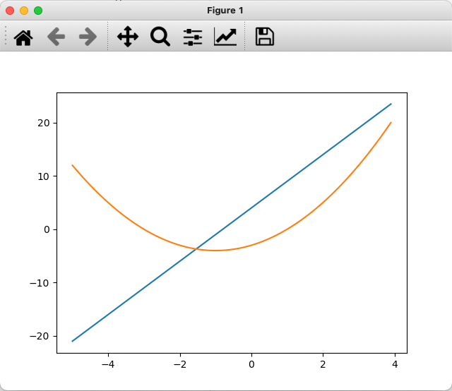

## Legend

- Every plot in an axes pair should have a name.
- This name is shown in the legend area.
- `legend` is a function of the axes object.

## Legend: Code

```python
import numpy as np
import matplotlib.pyplot as plt

# generate x array
x = np.arange(-5, 4, .1)

# calculate y and d
y = 5*x + 4
d = x**2 + 2*x - 3

# create figure and axes objects
fig, ax = plt.subplots(1, 1)
line1, = ax.plot(x, y)
line2, = ax.plot(x, d)

# create legend
ax.legend([line1, line2], ['y curve', 'd curve'])
```

## Legend: Result

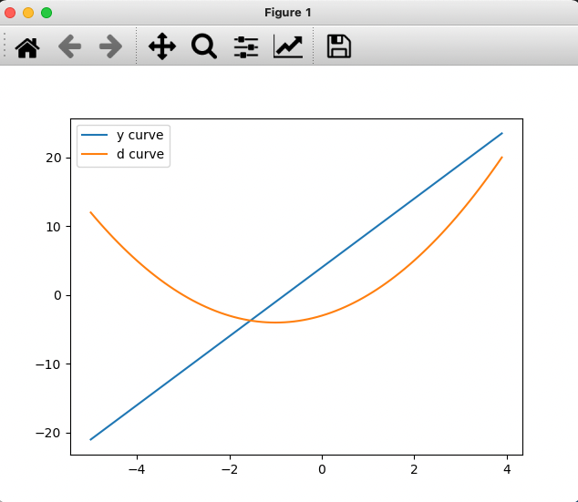

## Axes Labels

- In a reliable plot, every axis should have a name and a unit.
- In cartesian coordinates, axes are perpendicular.

```python
ax.set_xlabel('This is X axis')
ax.set_ylabel('This is Y axis')
```

## Axes Labels: Code

```python
import numpy as np
import matplotlib.pyplot as plt

# generate x array
x = np.arange(-5, 4, .1)

# calculate y and d
y = 5*x + 4
d = x**2 + 2*x - 3

# create figure and axes objects
fig, ax = plt.subplots(1, 1)
line1, = ax.plot(x, y)
line2, = ax.plot(x, d)

# create legend
ax.legend([line1, line2], ['y curve', 'd curve'])

# put axis labels
ax.set_xlabel('This is X axis')
ax.set_ylabel('This is Y axis')
```

## Axes Labels: Result

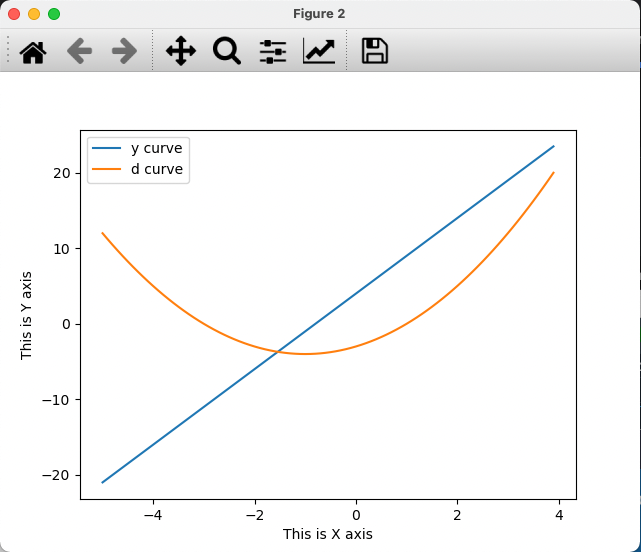

## Grids

- For an easier visual follow of plot values on a graph, grids are also desired.
- To put a grid, call the `grid()` function with a `True` bool:

```python
ax.grid(True)
```

- Without any input, it will **toggle** grid lines (turn them on if presently off and vice versa).

## Grids: Result

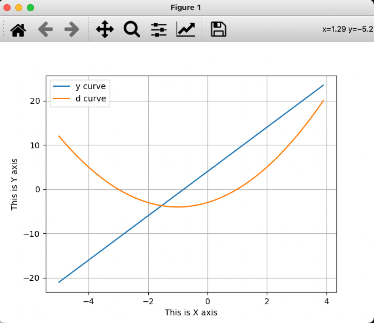

## Axis Limits

- Axis limits are automatically set,
- but can be manually assigned:

```python
ax.set_xlim(left, right)
ax.set_ylim(bottom, top)
ax.axis([xmin, xmax, ymin, ymax])
```

## Example: Trigonometric Plots

Sample the sine function with `np.linspace`, once coarsely and once densely:

```python
import numpy as np
import matplotlib.pyplot as plt

x10 = np.linspace(0, 2*np.pi, 10)
y_10pts = np.sin(x10)

x50 = np.linspace(0, 2*np.pi, 50)
y_50pts = np.sin(x50)

fig, ax = plt.subplots(1, 1)
line1, = ax.plot(x10, y_10pts, marker='.', markersize=8, ls='-')
ax.set_title('sine wave (10 pts)')
ax.set_xlabel('Phase (radians)')
ax.grid(True)

fig2, ax2 = plt.subplots(1, 1)
line2, = ax2.plot(x50, y_50pts, marker='.', markersize=8, ls='-')
ax2.set_title('sine wave (50 pts)')
ax2.set_xlabel('Phase (radians)')
ax2.grid(True)
```

Related functions: `np.sin(x)`, `np.cos(x)`, `np.tan(x)`

## Continuous vs Discrete Plot

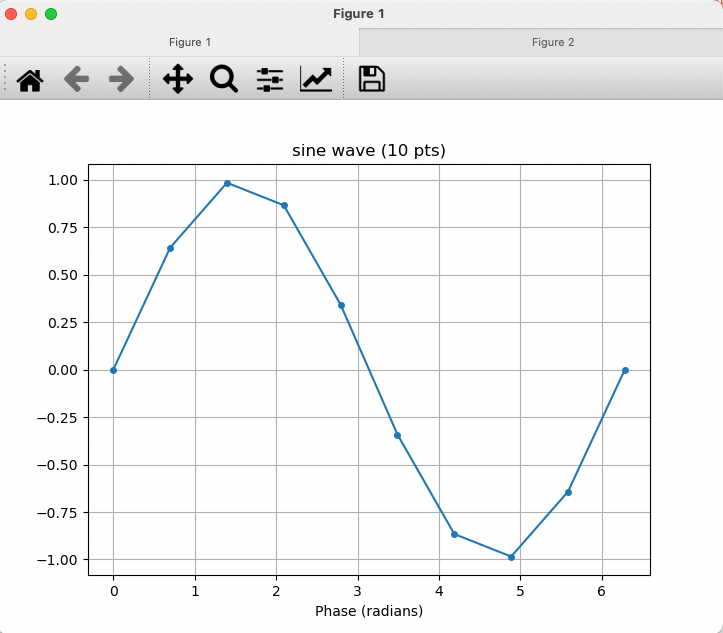

10 points: the sine wave looks angular - the sampling is too coarse.

## Continuous vs Discrete Plot (2)

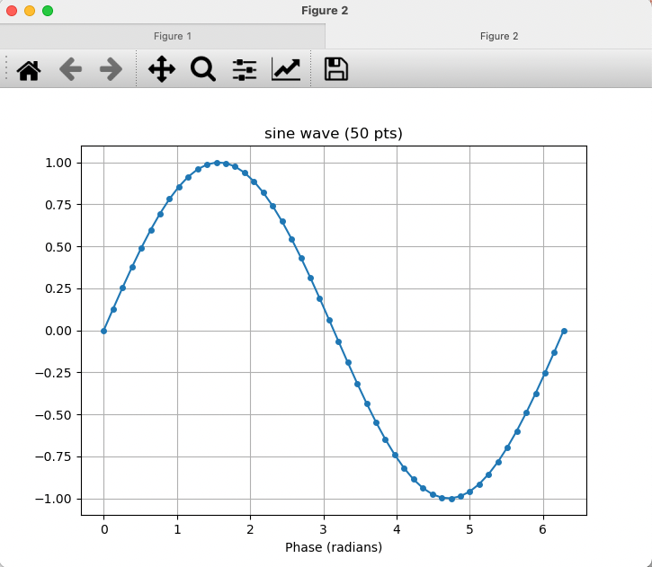

50 points: the same curve now looks smooth and continuous.

# Part 4: Logarithmic Plots and Subplots

## Logarithmic Plots

Any of the axes can be adjusted to logarithmic scale:

| Function | X axis | Y axis |
| --- | --- | --- |
| `plot()` | linear | linear |
| `loglog()` | log | log |
| `semilogx()` | log | linear |
| `semilogy()` | linear | log |

## Example: Filter Output

- In signal processing, a **filter** is a device or process that removes some unwanted components or features from a signal.
- Below you can see different frequency responses of different filters.

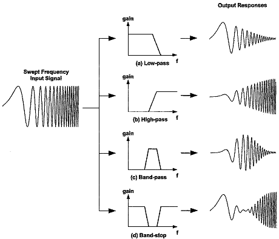

## `plot`: Linear X and Y Scales

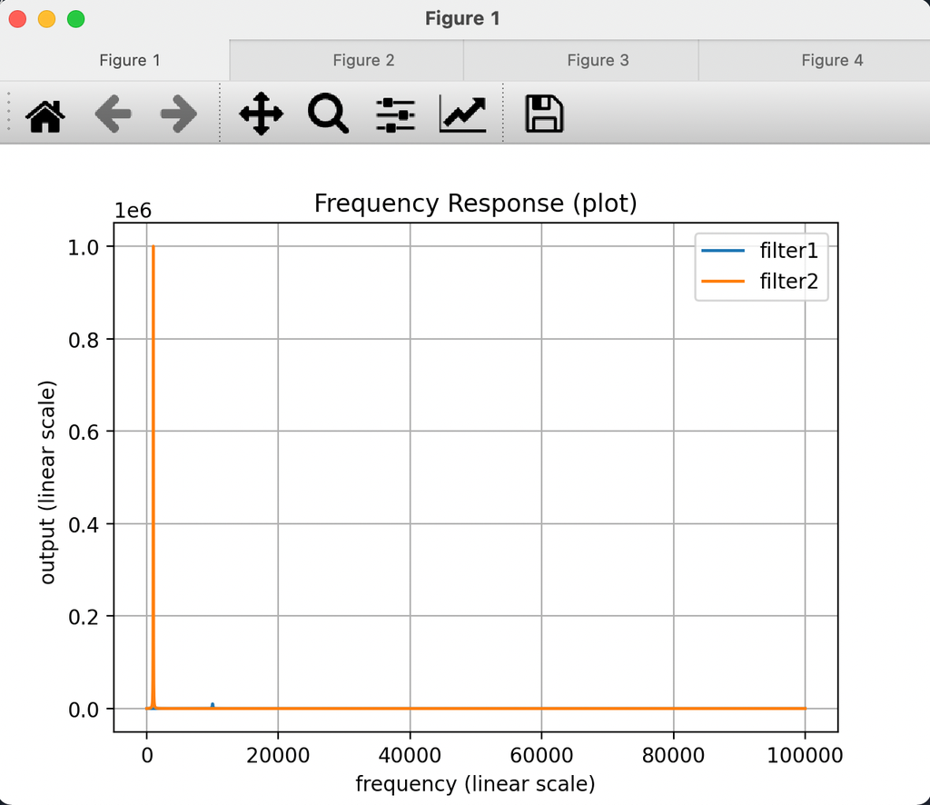

```python
import numpy as np
import matplotlib.pyplot as plt

w = np.linspace(10, 100000, 1000000)
s1 = 1e12*w/(np.sqrt((1e8-w**2)**4 + (1e8*w)**2))
s2 = 1e12*w/(np.sqrt((1e6-w**2)**4 + (1e6*w)**2))

fig, ax = plt.subplots(1, 1)
ax.plot(w, s1)
ax.plot(w, s2)
ax.legend(['filter1', 'filter2'])
ax.set_title('Frequency Response (plot)')
ax.set_xlabel('frequency (linear scale)')
ax.set_ylabel('output (linear scale)')
ax.grid(True)
```

Signals’ evolution in x and y scales is not clear.

## `semilogx`: Logarithmic X, Linear Y

```python
fig, ax = plt.subplots(1, 1)
ax.semilogx(w, s1)
ax.semilogx(w, s2)
ax.legend(['filter1', 'filter2'])
ax.set_title('Frequency Response (semilogx)')
ax.set_xlabel('frequency (log scale)')
ax.set_ylabel('output (linear scale)')
ax.grid(True)
```

Better in terms of x-axis position of the signals.

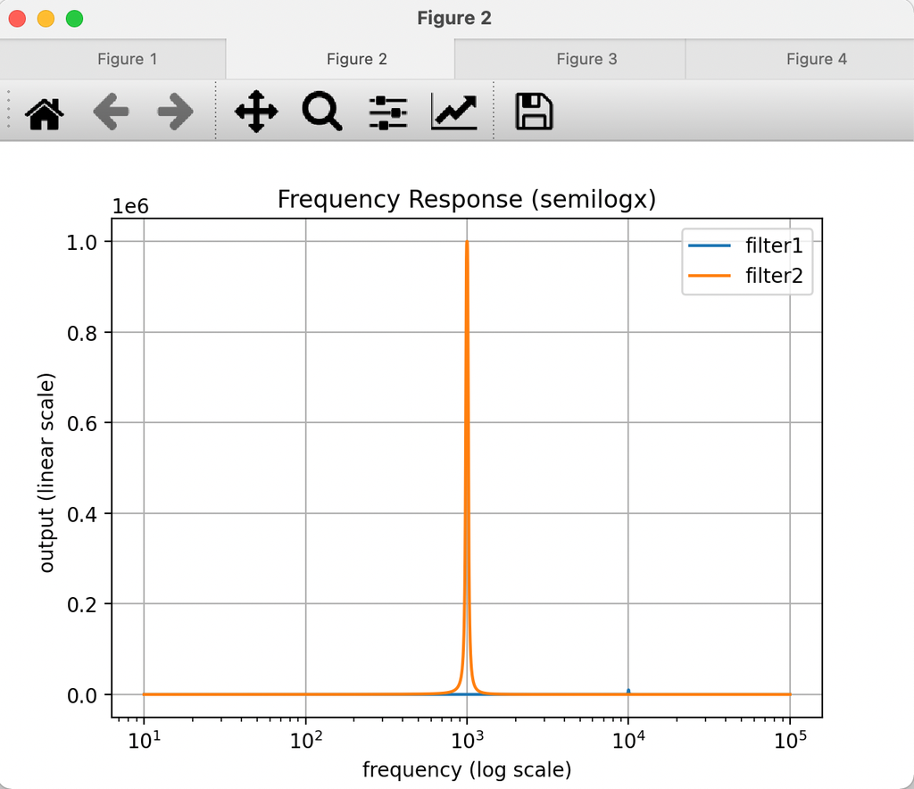

## `semilogy`: Linear X, Logarithmic Y

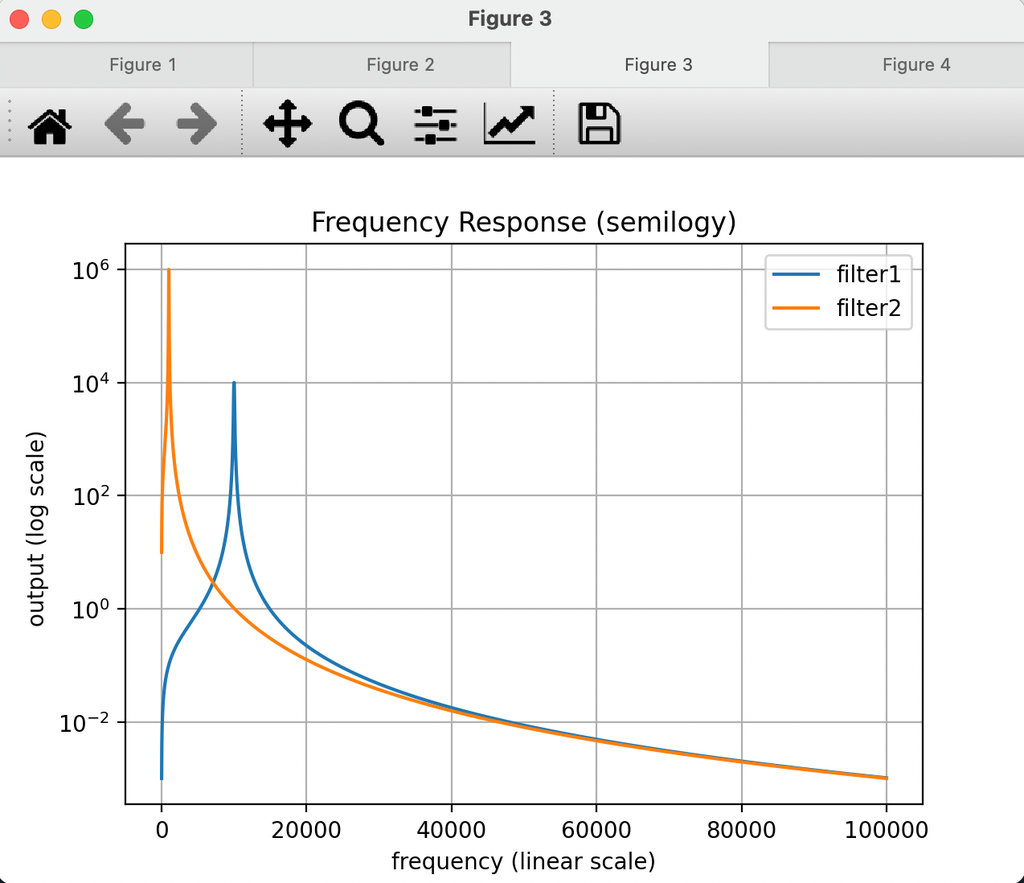

```python
fig, ax = plt.subplots(1, 1)
ax.semilogy(w, s1)
ax.semilogy(w, s2)
ax.legend(['filter1', 'filter2'])
ax.set_title('Frequency Response (semilogy)')
ax.set_xlabel('frequency (linear scale)')
ax.set_ylabel('output (log scale)')
ax.grid(True)
```

## `loglog`: Both Axes in Log Scale

```python
fig, ax = plt.subplots(1, 1)
ax.loglog(w, s1)
ax.loglog(w, s2)
ax.legend(['filter1', 'filter2'])
ax.set_title('Frequency Response (loglog)')
ax.set_xlabel('frequency (log scale)')
ax.set_ylabel('output (log scale)')
ax.grid(True)
```

A better view, as both x and y axis data have large ranges.

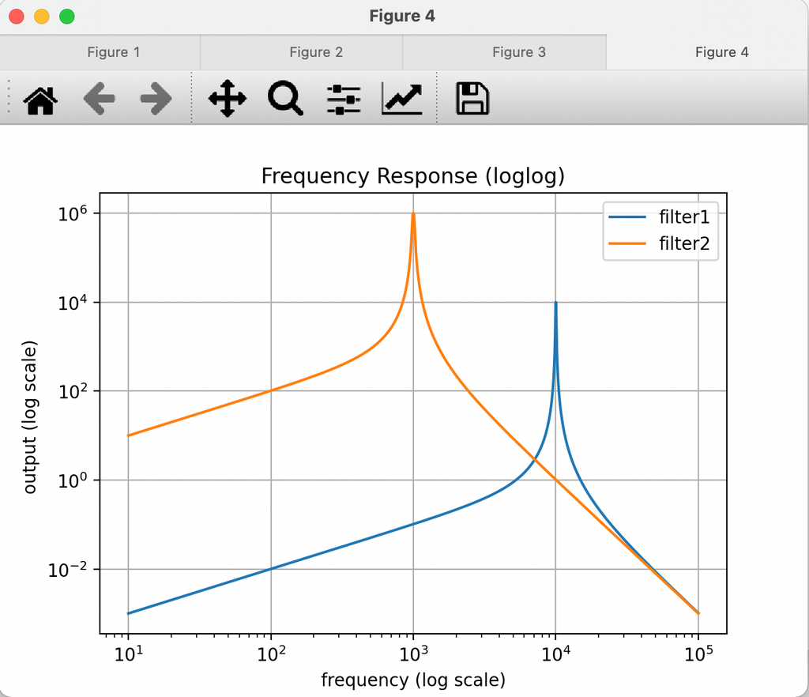

## Subplots

Call the subplot function with more than one axes:

[figure not shown]

```python
fig, ax = plt.subplots(1, 1)   # 1 row, 1 column

fig, axs = plt.subplots(2, 1)  # 2 rows, 1 column
axs[0].plot(x, y)
axs[1].plot(x, d)
```

## Subplots: 2 x 2 Grid

With `fig, ax = plt.subplots(2, 2)`, the axes are indexed as `ax[0,0]`, `ax[0,1]`, `ax[1,0]`, `ax[1,1]`:

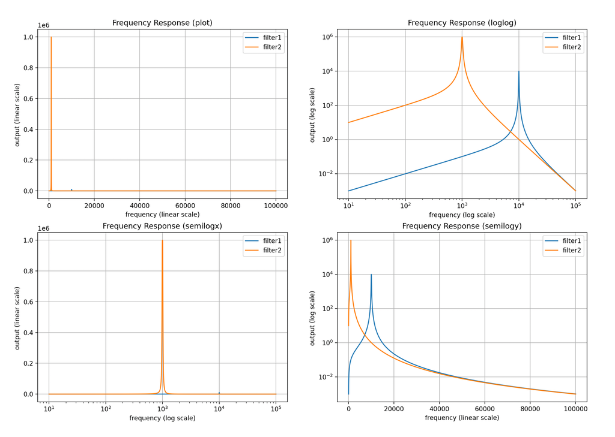

## Subplots: 2 x 2 Grid - Code

All four filter-response views in one figure:

```python
fig, ax = plt.subplots(2, 2)

ax[0,0].plot(w, s1)
ax[0,0].plot(w, s2)
ax[0,0].legend(['filter1', 'filter2'])
ax[0,0].set_title('Frequency Response (plot)')
ax[0,0].set_xlabel('frequency (linear scale)')
ax[0,0].set_ylabel('output (linear scale)')
ax[0,0].grid(True)

ax[0,1].loglog(w, s1)
ax[0,1].loglog(w, s2)
ax[0,1].legend(['filter1', 'filter2'])
ax[0,1].set_title('Frequency Response (loglog)')
ax[0,1].set_xlabel('frequency (log scale)')
ax[0,1].set_ylabel('output (log scale)')
ax[0,1].grid(True)

ax[1,0].semilogx(w, s1)
ax[1,0].semilogx(w, s2)
ax[1,0].legend(['filter1', 'filter2'])
ax[1,0].set_title('Frequency Response (semilogx)')
ax[1,0].set_xlabel('frequency (log scale)')
ax[1,0].set_ylabel('output (linear scale)')
ax[1,0].grid(True)

ax[1,1].semilogy(w, s1)
ax[1,1].semilogy(w, s2)
ax[1,1].legend(['filter1', 'filter2'])
ax[1,1].set_title('Frequency Response (semilogy)')
ax[1,1].set_xlabel('frequency (linear scale)')
ax[1,1].set_ylabel('output (log scale)')
ax[1,1].grid(True)
```

## Other 2D Graph Types

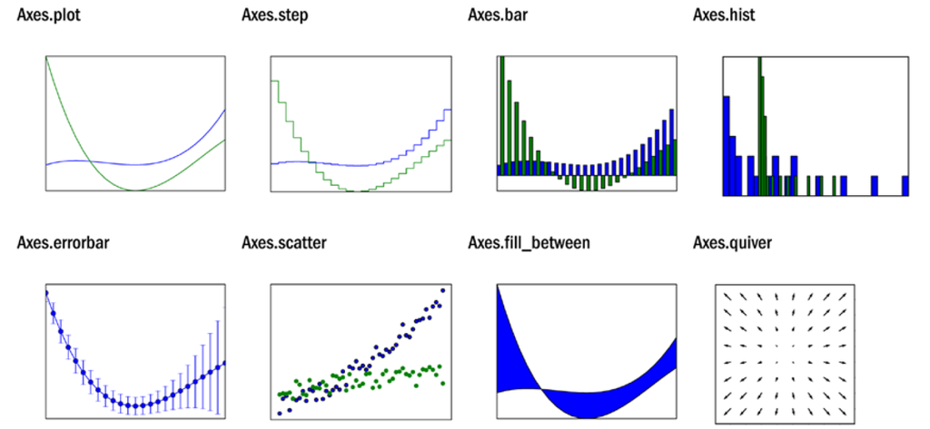

# Part 5: Complex Numbers and Polar Plots

## Complex Numbers

- For real numbers $a$ and $b$, any complex number $a + bj$ is located on the Euclidean plane $\mathbb{R}^2$ with coordinate pair $(a, b)$.
- This plane is called the **Complex Plane**.
  - X-axis = Real component
  - Y-axis = Imaginary component

## Norm and Phase

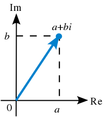

- The distance from the origin (on the complex plane) is the **NORM**.
- The rotation angle from the real axis is the **PHASE**.

## Polar Representation

- Any complex number on the complex plane has:
  - A distance from origin (called **NORM**)
  - A rotation angle from the real axis (called **PHASE**)
- These two parameters are very important in complex numbers.
- Any complex number can be represented by its norm and phase.
- This representation can be mapped to the same point using **polar coordinates**: in polar coordinates, norm and phase constitute the coordinate pair.

## Complex Numbers and Python

```python
>>> a = 3 + 4j
>>> b = 5 + 12j
>>> abs(a)
5.0
>>> abs(b)
13.0
>>> a*b
(-33+56j)
>>> a/b
(0.37278106508875736-0.09467455621301774j)
>>> a+b
(8+16j)
>>> a-b
(-2-8j)
```

```python
>>> import numpy as np
>>> np.angle(a)
0.9272952180016122
>>> np.rad2deg(np.angle(a))
53.13010235415598
>>> a.real
3.0
>>> a.imag
4.0
```

- `abs()` gives the norm, `np.angle()` gives the phase.

## Polar Plot

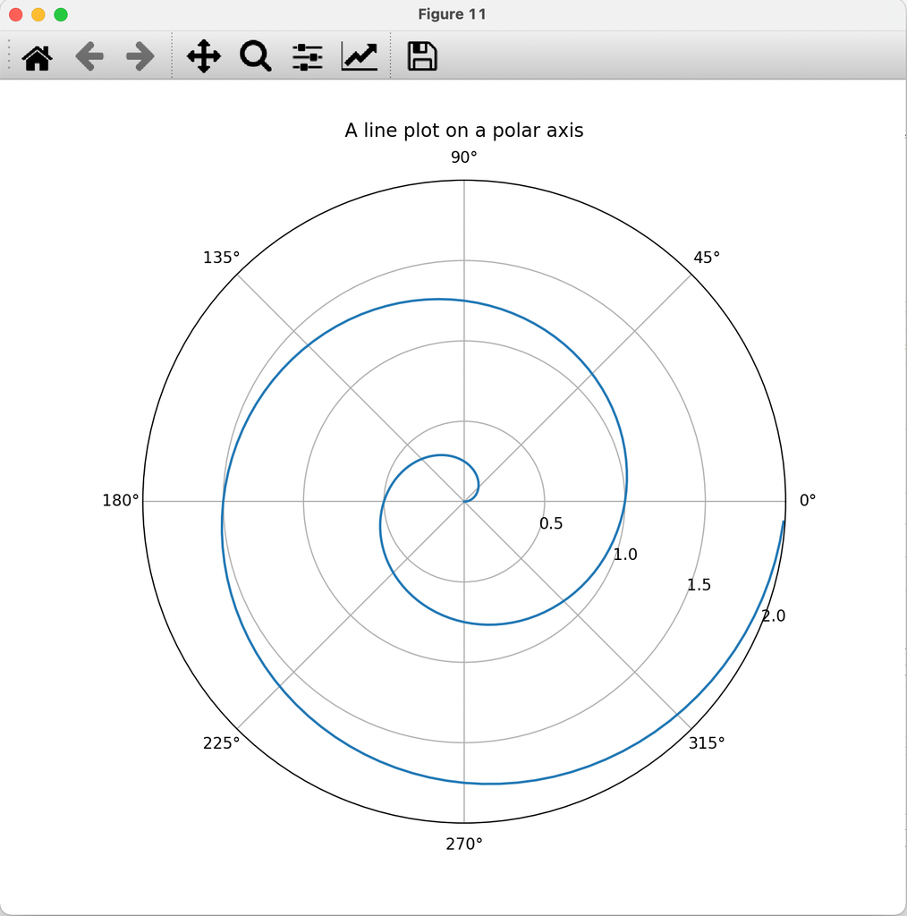

```python
import numpy as np
import matplotlib.pyplot as plt

r = np.arange(0, 2, 0.01)
theta = 2 * np.pi * r

fig, ax = plt.subplots(subplot_kw={'projection': 'polar'})
ax.plot(theta, r)
ax.set_rmax(2)
ax.set_rticks([0.5, 1, 1.5, 2])  # fewer radial ticks
ax.set_rlabel_position(-22.5)    # move radial labels
ax.grid(True)

ax.set_title("A line plot on a polar axis", va='bottom')
plt.show()
```

## Summary

- A matplotlib graphic is built from **figure**, **axes**, and **line** objects: `fig, ax = plt.subplots()` then `ax.plot(x, y)`.
- Markers, colors, line widths, and line styles are set with keyword arguments of `plot()`.
- Readable plots need titles, axis labels, legends, grids, and sensible axis limits.
- `semilogx`, `semilogy`, and `loglog` reveal behavior that linear scales hide.
- `plt.subplots(rows, cols)` places several axes in one figure.
- Complex numbers have a norm and a phase and map naturally onto **polar plots**.

## Reference

- https://matplotlib.org/